# Has slower business dynamism been associated with slower productivity growth for US sectors?

Author

Affiliation

Oliver Gregory

London School of Economics

Published

May 25, 2025

Abstract

This paper examines the relationship between declining business dynamism and productivity growth in US sectors, exploring why these trends have diverged over the past 30 years. Business dynamism has traditionally been seen as a key driver of productivity growth through the mechanism of creative destruction, so understanding why this relationship has weakened is essential. The paper analyses long-term trends in dynamism, productivity, and innovation, estimates firm-level markups and productivity, and performs a panel regression. The results suggest that productivity growth has not declined in parallel with business dynamism, likely due to increased market power and R&D investment enabling incumbents to ‘creatively destroy’ themselves.

## Introduction

Business dynamism has long been regarded as a key driver of productivity growth. According to the theory of creative destruction, a dynamic economy fosters innovation by allowing more productive entrants to displace less efficient incumbents. Indicators such as the job reallocation rate, firm entry and exit rates, and resource reallocation are strong indicators of this mechanism, which theoretically drives aggregate productivity upward. However, over the past few decades, several common measures of business dynamism have steadily declined. As shown in Figure 1, the job reallocation rate – a summary statistic of the pace at which jobs shift across firms – fell from roughly 30% in 1992 to about 23% in 2020. This approximately 25% decline, suggests a meaningful slowdown in the rate at which workers are being reallocated across roles, potentially implying reduced productivity growth and innovation according to the theory.

Yet despite this decline in business dynamism, aggregate productivity growth has not followed a similarly downward trajectory. The five-year moving average of productivity growth in 2020 has hardly changed since 1992. This divergence raises an important question: if creative destruction is slowing, why has productivity growth not slowed down as well? Are there alternative mechanisms at work that help sustain aggregate productivity growth despite declining business dynamism?

To explore this question, I examine several key variables: the job reallocation rate, firm birth and death rates, total factor productivity (TFP) growth, firm markups, R&D spending, patent applications, and productivity dispersion. The job reallocation rate captures the rate at which jobs are created and destroyed across firms, and therefore reflects how rapidly labour is moving toward more productive uses. The firm birth and death rates serve as direct but nuanced indicators of creative destruction. A high firm death rate, for instance, is only indicative of a healthy competitive environment when accompanied by a high birth rate. On their own, such figures can also signal downturns or sectoral stagnation. TFP growth provides a measure of output not explained by labour and capital inputs, and therefore is a good proxy for technological progress. Firm-level markups help track shifts in market power, while R&D spending and patent filings offer an insight into the innovation strategies firms pursue to maintain or improve competitiveness.

This paper argues that although business dynamism has declined, productivity growth has remained resilient because of rising market concentration and the outsized influence of ‘superstar firms’. These firms, often leaders in their respective industries, have maintained high levels of productivity growth and driven investment in R&D, despite broader declines in entry rates and job reallocation. At the same time, rising markups suggest growing market power, which is concentrated within these firms. As market share reallocates toward highly productive incumbents, aggregate productivity can rise even if the broader ecosystem of firms becomes less dynamic. This pattern is consistent with Schumpeterian growth models, which emphasise the role of innovation-driven competition and strategic R&D investment by market leaders.

Empirical research also supports this view, for example, Autor et al. (2020) find that industries experiencing rising concentration often display faster, not slower, productivity growth. De Loecker et al. (2020) show that average firm markups have increased dramatically since 1980, with market share shifting toward high-markup firms. Aghion et al. (2005) highlight an inverted-U relationship between competition and innovation, where moderate levels of competition foster innovation. Meanwhile, Andrews et al. (2016) document a growing gap between productivity growth at frontier firms and laggards. Griffith et al. (2023) tie these trends to the Schumpeterian tradition, illustrating how innovation is often concentrated among a few firms that use R&D to preserve their leadership.

In what follows, I investigate these trends using US sectoral data and firm-level indicators to better understand how productivity growth can persist in an era of declining business dynamism.

## Data and Empirical Strategy

This paper combines a descriptive and econometric approach to examine the relationship between business dynamism, productivity growth, and market concentration in the United States over the past three decades. First, I document long-term trends in key indicators of business dynamism, including job reallocation rates, and firm entry and exit rates. I compare these to aggregate productivity growth patterns. The aim is to establish whether the decline in dynamism was accompanied by slower productivity growth.

To formally test this relationship at the sectoral level, I conduct a panel regression using sector-level data, including fixed effects to control for time-invariant differences across sectors, and controlling for output. The dependent variable is total factor productivity (TFP) growth, while key independent variables include the job reallocation rate and firm birth and death rates. This setup allows me to evaluate whether there is a statistically significant association between business dynamism and productivity growth. The equation I will estimate is as follows:
$$\text{TFP}_{st} = \alpha_{st} + \theta_1\text{fdr}_{st} + \theta_2\text{fbr}_{st} + \theta_3\text{jrr}_{st} + \beta y_{st} + \beta_s + \gamma_t + \epsilon_{st}$$

where $\theta_1, \theta_2, \theta_3$ are the coefficients of interest on the firm death rate, firm birth rate and job reallocation rate respectively. $y_{st}$ represents the sector’s output and $\beta_s, \gamma_t$ are sector and time fixed effects respectively.

To further understand the underlying mechanisms, I estimate firm-level markups and productivity using methodologies outlined in Ackerberg et al. (2015), and De Loecker et al. (2020). These estimates allow me to track trends in markup dispersion and productivity dispersion across firms, particularly focusing on the upper tails of the distribution (e.g., 95th, 80th percentiles). I also examine how R&D investment and patenting activity have evolved over time, assessing whether innovation has increased during this period.

The analysis draws on several key data sources: the US Business Dynamics Statistics (BDS) for firm entry, exit, and job flows; the Bureau of Labor Statistics (BLS) for sectoral TFP and output; Compustat for firm-level financial data used in markup estimation; the US Patent and Trademark Office (USPTO) for patent data; and FRED for R&D spending.

The analytical framework is grounded in the Schumpeterian model of growth, which posits that firms with higher profits invest more in R&D, leading to faster productivity growth. This suggests that rising market concentration, by increasing profitability at the top, can sustain productivity growth even in an environment of declining dynamism, while also contributing to greater productivity dispersion.

## Discussion

### Business Dynamism and Productivity Growth Patterns

Economic theory suggests a strong link between productivity growth and business dynamism. One key mechanism behind this is creative destruction, a process where less productive incumbent firms are replaced by newer, more innovative entrants. These new firms often introduce improved technologies or more efficient practices, thereby raising overall productivity. This implies that periods of high business dynamism should be associated with faster productivity growth.

However, this relationship is not guaranteed. It may also be the case that incumbent firms remain more productive than new entrants, especially if they continue to invest in innovation and efficiency improvements. In such cases, productivity growth might not depend on firm turnover. Furthermore, other factors could explain a decline in dynamism. Increased regulation may raise barriers to entry, reducing the flow of new firms into markets. Greater industry concentration and market power among incumbents could also stifle competition, for example, through predatory pricing or strategic acquisitions, without necessarily causing a fall in productivity.

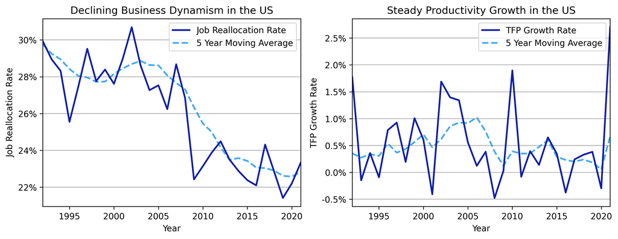

Figure 1: Creative destruction vs productivity growth. (U.S. Bureau of Labor Statistics, 2024) (U.S. Census Bureau, 2024)

Table 1: Panel regression results of TFP growth on business dynamism measures.

|  | Parameter | Std. Err. | T-stat | P-value | Lower CI | Upper CI |
| --- | --- | --- | --- | --- | --- | --- |
| const | -0.0013 | 0.0147 | -0.0898 | 0.9285 | -0.0301 | 0.0275 |
| firm_death_rate | 0.3373 | 0.1603 | 2.1041 | 0.0358 | 0.0224 | 0.6521 |
| firm_birth_rate | -0.0003 | 0.0005 | -0.6212 | 0.5347 | -0.0012 | 0.0006 |
| job_reallocation_rate | -0.0772 | 0.0449 | -1.7202 | 0.0860 | -0.1655 | 0.0110 |
| output | 0.0027 | 0.0043 | 0.6416 | 0.5214 | -0.0057 | 0.0112 |

Table 1 presents the results of such a regression, using firm birth rates, firm death rates, and the job reallocation rate as proxies for business dynamism. The findings suggest no strong or consistent relationship between these measures and TFP growth. The only statistically significant result is the firm death rate, which appears positively associated with productivity growth. However, interpreting this result is challenging. As noted earlier, a rising death rate alone does not necessarily reflect increased dynamism, especially if it is not accompanied by a corresponding rise in the birth rate. Since the birth rate is not significantly correlated with productivity growth in this model nor clearly different from 0, the significance of the death rate may reflect other dynamics, such as unproductive firms exiting during recessions, rather than the healthy process of creative destruction.

Even when firm birth and death rates are excluded and the regression focuses solely on the job reallocation rate, the relationship with TFP growth remains statistically insignificant. In other words, across a range of specifications, there is little evidence to support a robust link between business dynamism and productivity growth in the data.

This raises an important question: if business dynamism has declined, why has productivity growth not shown a consistent downward trend? One possibility is that productivity gains in recent decades have come increasingly from within firms, particularly large incumbents that have invested heavily in technology, automation, and process improvements. This shift would weaken the traditional assumption of a link between business dynamism and productivity growth.

### Market Concentration, Markups and R&D

A similar pattern that has emerged over the last 30 years in the US has been a strong increase in the market concentration and the markup charged by firms. For example, De Loecker et al. (2020) find that average markups in the US increased from 21% in 1980 to 61% in 2020 implying a significant increase in the pricing and market power of incumbent firms over that period.

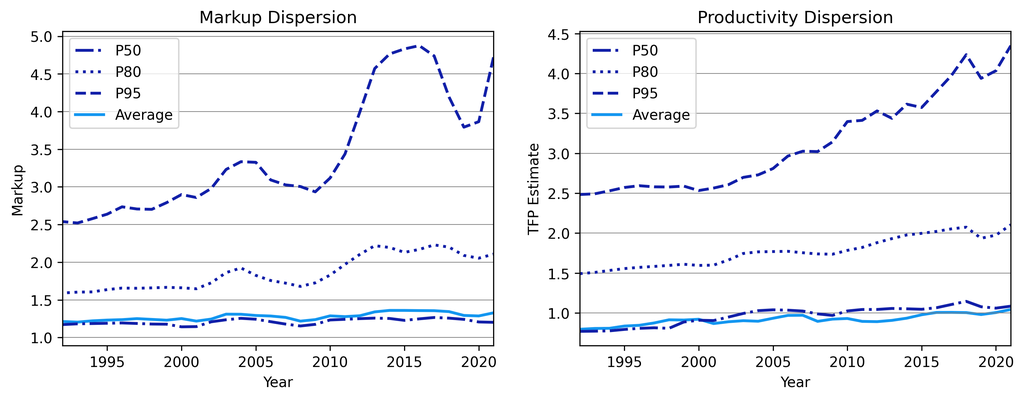

Figure 2: Increasing productivity and markup dispersion. (Compustat, 2024)

Rising markups translate into higher firm profitability, which, according to Schumpeterian growth theory (Aghion & Howitt, 1992), plays a key role in driving innovation. Profitable firms have a greater financial capacity to invest in R&D and also a stronger incentive to do so, as innovation helps them maintain or extend their lead in concentrated markets. Leading firms may therefore reinvest their profits to defend their competitive position and create higher barriers to entry.

This theoretical link is reflected in the empirical data. Figure 3 shows consistent year-on-year increases in real R&D spending in the US, alongside a rising number of US originated patents being filed. While causality is complex, the co-movement of rising markups, market concentration, and innovation inputs suggests that the accumulation of market power may be enabling, rather than stifling, innovation – at least among incumbent firms.

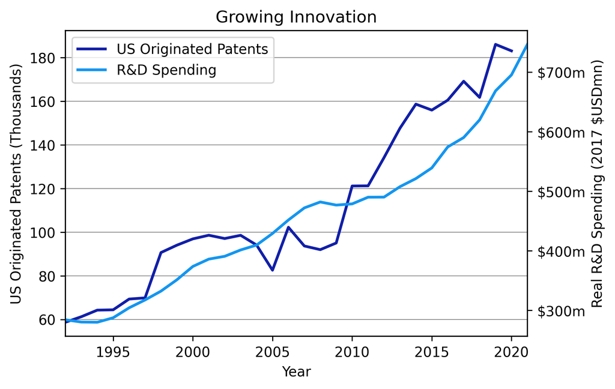

Figure 3: Growing real R&D spending and patent filings. (Federal Reserve Bank of St. Louis, 2024) (U.S. Patent and Trademark Office, 2024)

### Productivity Dispersion

Alongside the rise in markups, Figure 2 also reveals a marked increase in productivity dispersion over the same period. This trend is especially pronounced at the top of the distribution. Firms in the 95th percentile of markups increased their markups by just over 80% between 1992 and 2021, while firms in the 95th percentile of productivity saw their productivity rise by just under 80%. A similar pattern appears at the 80th percentile, where both metrics grew by just over a third.

While we cannot definitively establish a causal link, the similarity is nonetheless striking. It suggests that rising market power and profitability may be enabling some firms to sustain strong productivity growth, potentially through reinvestment in technology and innovation.

This widening gap between the most productive and least productive firms is well-documented in recent literature. Studies on ‘superstar firms’ have noted how a small number of dominant players are increasingly responsible for aggregate productivity growth and innovation (Autor et al., 2020). These firms are able to pull ahead due to economies of scale, access to capital, and large R&D budgets, leaving smaller competitors further behind. This also ties in nicely with the inverted-U relationship between competition and innovation proposed by Aghion et al. (2005), where moderate levels of competition are able to spur innovation. However, that relationship also implies that too much concentration can stifle innovation, as firms may become complacent in the absence of competitive pressure. This is perhaps a concern for policy makers who may not want to breakup large firms as they are currently innovating, but could risk allowing them to become too powerful.

### A New Kind of Creative Destruction?

Traditionally, creative destruction refers to the process whereby new, more productive firms displace inefficient incumbents, driving productivity growth. However, the patterns observed in this analysis suggest the emergence of a new form of creative destruction, driven not by external disruption, but by the internal reinvention of incumbent firms.

As dominant firms gain market share and pricing power, they do not merely defend their positions by erecting barriers to entry; they actively invest in innovation to preempt potential challengers. Through sustained R&D spending and technological adoption, they continuously ‘destroy’ their own previous models and practices to remain competitive. This self-disruption allows incumbents to retain leadership roles in increasingly concentrated markets.

Rather than through firms continuously entering and exiting, today’s productivity frontier is shaped by firms that transform themselves faster than others can catch up. This model of innovation-driven consolidation may explain how productivity can rise even as traditional measures of business dynamism, such as firm entry/exit and job reallocation, are declining.

## Conclusion

This analysis set out to explore whether declining business dynamism in the United States has been associated with slower productivity growth. The answer, based on sector-level data from 1992 to 2021, appears to be no.

Measured through indicators such as job reallocation and firm entry rates, business dynamism has indeed declined in recent decades. However, total factor productivity (TFP) growth has remained relatively stable over the same period, with no clear downward trend. At the same time, the data reveals sharp increases in market concentration and firm markups, particularly among firms at the top of the distribution. These high-markup firms have also seen the strongest increases in productivity. In line with the Schumpeterian growth theory, rising profitability appears to be fuelling increased investment in research and development, as seen through sustained growth in real R&D spending and patenting activity.

Together, these trends have contributed to widening productivity dispersion. The top-performing firms are pulling further ahead, not because of increased competition from entrants, but because they are innovating from within and leveraging their market power to continuously improve and adapt. This dynamic points to a new kind of creative destruction, one in which incumbents disrupt themselves in order to maintain their dominance.

Nevertheless, several limitations must be acknowledged. The markup and productivity analysis relies on Compustat data, which covers only publicly listed firms, potentially omitting important dynamics in private or smaller enterprises. Moreover, heterogeneity across sectors may obscure more nuanced trends. Finally, while the relationships observed are interesting, establishing causality remains a significant challenge.

Overall though, the findings suggest that the mechanisms behind productivity growth may be shifting. As entry rates fall and competition diminishes, innovation increasingly appears to be driven by incumbent firms reinventing themselves. Whether this model of self-disruptive innovation can be sustained, and whether it benefits the broader economy, remains to be seen.

## References

Ackerberg, D. A., Caves, K., & Frazer, G. (2015). IDENTIFICATION PROPERTIES OF RECENT PRODUCTION FUNCTION ESTIMATORS. *Econometrica*, *83*(6), 2411–2451. http://www.jstor.org/stable/43866416

Aghion, P., Bloom, N., Blundell, R., Griffith, R., & Howitt, P. (2005). Competition and innovation: An inverted-u relationship*. *The Quarterly Journal of Economics*, *120*(2), 701–728. https://doi.org/10.1093/qje/120.2.701

Aghion, P., & Howitt, P. (1992). A model of growth through creative destruction. *Econometrica*, *60*(2), 323–351. http://www.jstor.org/stable/2951599

Andrews, D., Criscuolo, C., & Gal, P. N. (2016). *The best versus the rest: The global productivity slowdown, divergence across firms and the role of public policy* [OECD Productivity Working Papers]. *5*. https://doi.org/10.1787/63629cc9-en

Autor, D., Dorn, D., Katz, L. F., Patterson, C., & Van Reenen, J. (2020). The fall of the labor share and the rise of superstar firms. *Quarterly Journal of Economics*, *135*(2), 645–709. https://academic.oup.com/qje/article/135/2/645/5721266

Compustat. (2024). *Compustat north america*. S&P Global Market Intelligence. https://www.capitaliq.com

De Loecker, J., Eeckhout, J., & Unger, G. (2020). The rise of market power and the macroeconomic implications*. *The Quarterly Journal of Economics*, *135*(2), 561–644. https://doi.org/10.1093/qje/qjz041

Federal Reserve Bank of St. Louis. (2024). *Gross domestic product: Research and development [Y694RC1Q027SBEA]*. FRED, Federal Reserve Economic Data. https://fred.stlouisfed.org/series/Y694RC1Q027SBEA

Griffith, R., Reenen, J. V., & Macron, E. (2023). Product market competition, creative destruction, and innovation. In *The economics of creative destruction: New research on themes from aghion and howitt* (pp. 43–76). Harvard University Press. http://www.jstor.org/stable/jj.4820341.7

U.S. Bureau of Labor Statistics. (2024). *Productivity and costs: Industry productivity data*. Online database; U.S. Department of Labor. https://www.bls.gov/productivity/data.htm

U.S. Census Bureau. (2024). *Business dynamics statistics: Time series datasets*. Online database; U.S. Department of Commerce, Census Bureau. https://www.census.gov/data/datasets/time-series/econ/bds/bds-datasets.html

U.S. Patent and Trademark Office. (2024). *U.s. Granted patents: Total patents originating in the united states [PATENTUSALLTOTAL]*. FRED, Federal Reserve Economic Data, Federal Reserve Bank of St. Louis. https://fred.stlouisfed.org/series/PATENTUSALLTOTAL